# R Exercises - Load and plot multiple files

2021-09-27

In this typical exercise, we will learn how to read multiple files and plot them all together. This is the basic step of data analysis.

# 1 Reading the data files

- Load the `tidyverse` and `readxl` libraries

```r
library(tidyverse)
library(readxl)
```

- Store into `flist` the list of all `.xls` files in the `Data/` folder. Take a look at the `list.files()` function for this, and especially at its parameters `path`, `pattern`, and `full.names`.

```r
flist <- list.files(path="Data", pattern = ".xls", full.names = TRUE)
```

- Open one of the .xls files with Excel and study the structure of the file. At the top of the file, the first group of 2-column data is the blank measurement (columns A and B, lines 8 through 3408), while the second group under the blank is the actual raw measurement (columns A and B, lines 3413 through 6813). Working on the first file in the list, successively:
  - Read and store the blank data in a tibble called `blank.df`
  - Read and store the raw data in a tibble called `raw.df`
  - Combine them into a tibble called `alldata` containing the columns `w`, `blank`, `raw`, and `transmittance`, the later being the transmittance (in percent) with respect to the blank measurement (*i.e.* `transmittance = raw / blank * 100`).

The final table should look like this:

```r
blank.df <- read_excel(flist[1],
            range = "A8:B3408",
            col_names = c("w","blank"))
raw.df   <- read_excel(flist[1],
            range = "A3413:B6813",
            col_names = c("w","raw"))
# Base R version
alldata <- tibble(blank.df, raw=raw.df$raw)
alldata$transmittance <- alldata$raw/alldata$blank*100
alldata
```

```
## # A tibble: 3,401 × 4
##        w blank   raw transmittance
##    <dbl> <dbl> <dbl>         <dbl>
##  1  4000   100  94.2          94.2
##  2  3999   100  94.3          94.3
##  3  3998   100  94.2          94.2
##  4  3997   100  94.2          94.2
##  5  3996   100  94.2          94.2
##  6  3995   100  94.2          94.2
##  7  3994   100  94.2          94.2
##  8  3993   100  94.2          94.2
##  9  3992   100  94.2          94.2
## 10  3991   100  94.2          94.2
## # … with 3,391 more rows
```

```r
# Tidyverse version:
# alldata <- inner_join(blank.df, raw.df, by = "w") %>%
#     mutate(transmittance=raw/blank*100)
```

- Wrap this procedure into a function `readFTIR()` that, given a file name, returns a tibble with the columns `w`, `blank`, `raw`, and `transmittance`. This means you just need to do the same thing as before but providing the file name as a variable, and finish the function by printing the `alldata` tibble – if you don’t print it as the last action of your function, it won’t return the tibble. Test it on the first file in the list.

```r
readFTIR <- function(filename) {
    blank.df <- read_excel(filename,
                range = "A8:B3408",
                col_names = c("w","blank"))
    raw.df   <- read_excel(filename,
                range = "A3413:B6813",
                col_names = c("w","raw"))
    # Base R version
    alldata <- tibble(blank.df, raw=raw.df$raw)
    alldata$transmittance <- alldata$raw/alldata$blank*100
    alldata
    # Tidyverse version:
    # inner_join(blank.df, raw.df, by = "w") %>%
    #     mutate(transmittance=raw/blank*100)
}
```

- Plot the first file in `flist`, and try to make your plot look like this:

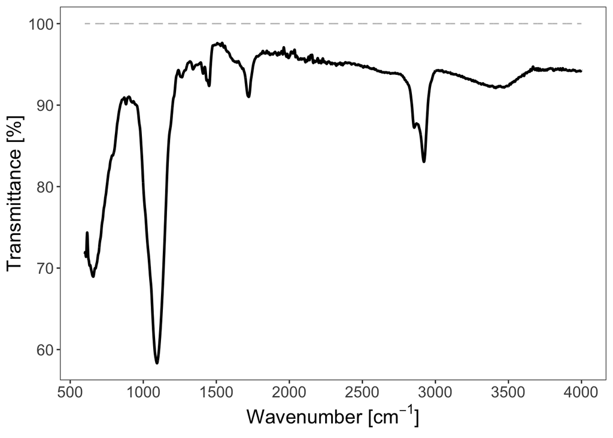

```r
readFTIR(flist[1]) %>%
    ggplot(aes(x=w, y=raw))+
        geom_line(size=1)+
        geom_line(aes(y=blank), lty=2, col="gray")+
        labs(x=expression(paste("Wavenumber [", cm^{-1},"]")),
             y="Transmittance [%]")+
        scale_x_continuous(breaks=seq(0,5000,500))+
        theme_bw()+
        theme(panel.grid=element_blank(),
              text=element_text(size=16))
```

- Now we want to read all files in the list and store them in a tidy tibble. For this we will start easy and use a `for` loop. This is the step-by-step procedure:
  - Define an empty tibble called `df`
  - Define a `for` loop on all elements of `flist`
  - Then, within this `for` loop, successively:
    - Read the current file with the above-defined `readFTIR()` function and store it in `tempdf`
    - Add the column `name` to `tempdf` containing the current file name. If needed, trim the path from the name string using `basename()`.
    - Stack `tempdf` below `df` by binding them row-wise (look at `bind_rows()`).

The final table should look like this:

```r
df <- tibble()
for(file in flist){
    tempdf <- readFTIR(file)
    tempdf$name <- basename(file)
    df <- bind_rows(df, tempdf)
}
df
```

```
## # A tibble: 34,010 × 5
##        w blank   raw transmittance name
##    <dbl> <dbl> <dbl>         <dbl> <chr>
##  1  4000   100  94.2          94.2 sample_0_25C.xls
##  2  3999   100  94.3          94.3 sample_0_25C.xls
##  3  3998   100  94.2          94.2 sample_0_25C.xls
##  4  3997   100  94.2          94.2 sample_0_25C.xls
##  5  3996   100  94.2          94.2 sample_0_25C.xls
##  6  3995   100  94.2          94.2 sample_0_25C.xls
##  7  3994   100  94.2          94.2 sample_0_25C.xls
##  8  3993   100  94.2          94.2 sample_0_25C.xls
##  9  3992   100  94.2          94.2 sample_0_25C.xls
## 10  3991   100  94.2          94.2 sample_0_25C.xls
## # … with 34,000 more rows
```

- More advanced: you can do this without using a `for` loop using the `tidyverse`. For this, look into the `map()` function as described [here](https://lmi.cnrs.fr/r/data-frames.html#apply-a-function-recursively-on-each-element-of-a-column).

```r
df  <- tibble(name = flist) %>%
    mutate(data=map(name, ~readFTIR(.)),
           name=basename(name)) %>%
    unnest(data)
write.csv(df,"Data/alldata.csv", row.names=FALSE)
```

# 2 Plotting

In case you didn’t manage to do the above procedure, just load the `alldata.csv` file in the `Data` folder by running `df <- read_csv("Data/alldata.csv")`.

We will now plot all these files together using `ggplot2`.

- First, you can try several things, like:
  - Plot them all together in one frame with a color depending on the file name.
  - Plot them all on a different frame (look at `facet_wrap()`) for each file.

The final plots should look like this:

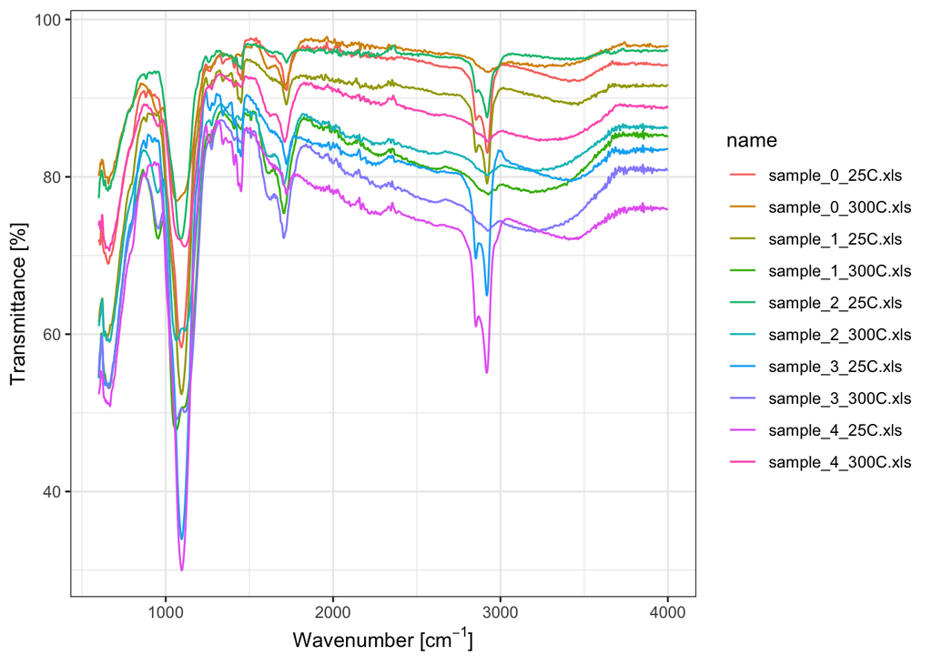

```r
theme_set(theme_bw()+
          theme(strip.background = element_blank(),
                strip.text = element_text(face="bold")))
ggplot(data=df, aes(x=w, y=transmittance, color=name))+
    geom_line()+
    labs(x=expression(paste("Wavenumber [", cm^{-1},"]")),
         y="Transmittance [%]")
```

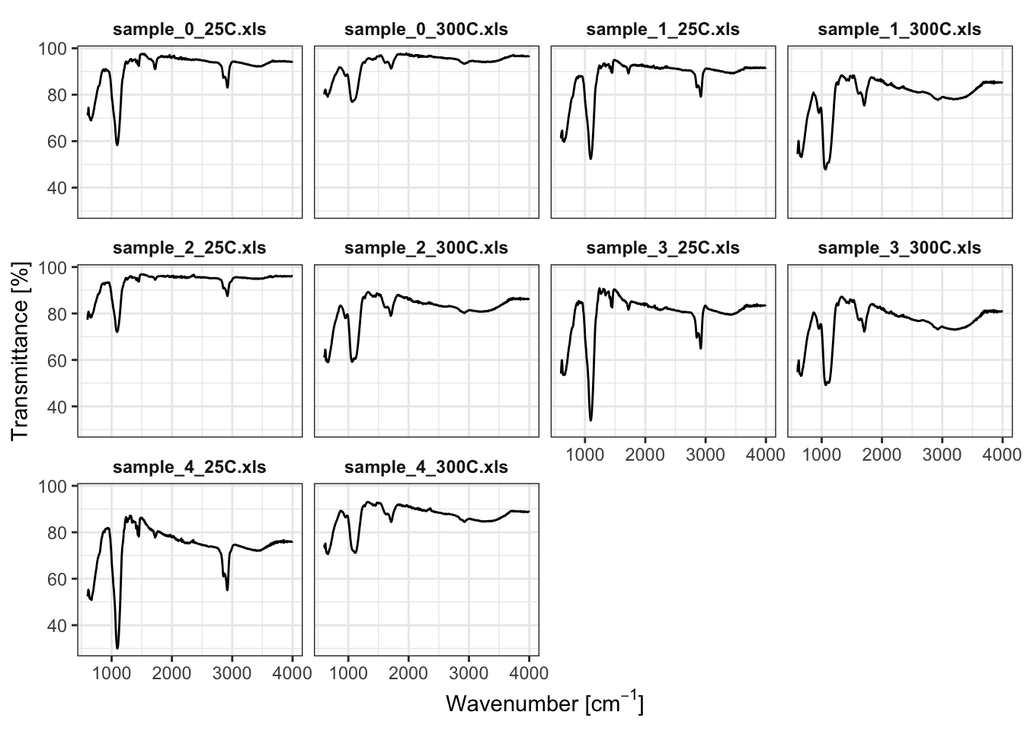

```r
ggplot(data=df, aes(x=w, y=transmittance))+
    geom_line()+
    labs(x=expression(paste("Wavenumber [", cm^{-1},"]")),
         y="Transmittance [%]")+
    facet_wrap(~name)
```

- You see in the file names that there are actually 5 samples with 2 temperatures for each sample. Based on the column `name` of the `df` tibble, create the columns `sample` and `temperature` that contain *numerical values* of the sample number and temperature. Think about using the function `gsub()` to replace (delete) text in a string, the `substr(string, start, end)` function to get a portion of a string. You can also take a look at the `separate()` function from the `tidyverse` (see [here](https://lmi.cnrs.fr/r/data-frames.html#separate-columns)).

```r
# Base version
df$sample      <- as.numeric(substr(df$name,8,8))
df$temperature <- substr(df$name,10,20)
df$temperature <- as.numeric(gsub("C.xls","",df$temperature))
# tidyverse version
df  <- tibble(name = flist) %>%
    mutate(data=map(name, ~readFTIR(.)),
           name=basename(name)) %>%
    separate(name, c(NA, "sample","temperature",NA), convert = TRUE) %>%
    mutate(temperature=as.numeric(gsub("C","",temperature))) %>%
    unnest(data)
```

- Now it is time to make nicer plots:
  - Make a grid plot showing the data evolution for each sample as a function of temperature
  - Make a grid plot with one frame per sample, and the two temperatures in different colors.

The final plots should look like this:

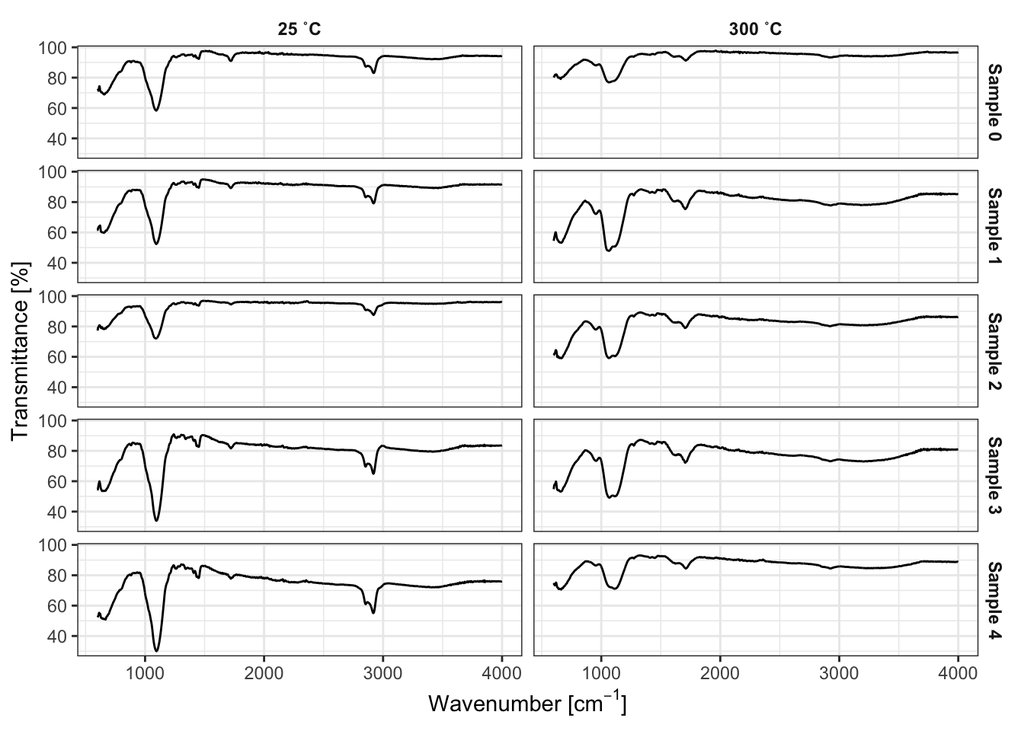

```r
ggplot(data=df, aes(x=w, y=transmittance))+
    geom_line()+
    labs(x=expression(paste("Wavenumber [", cm^{-1},"]")),
         y="Transmittance [%]")+
    facet_grid(paste("Sample", sample) ~ paste(temperature,"˚C"))
```

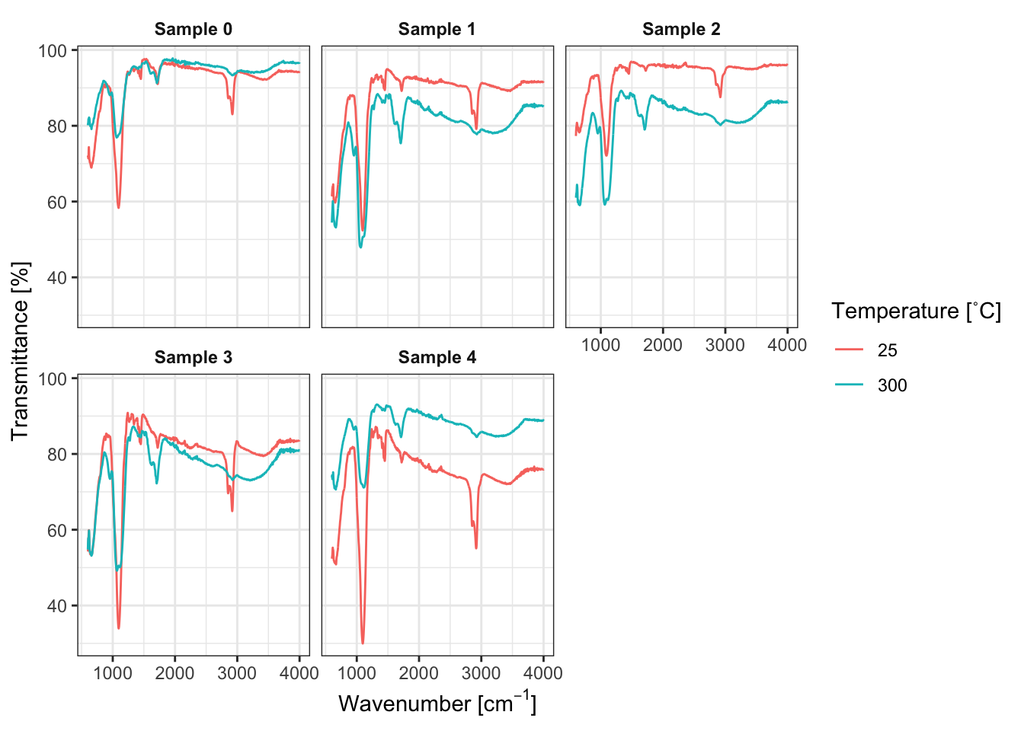

```r
ggplot(data=df, aes(x=w, y=transmittance, color=factor(temperature)))+
    geom_line()+
    labs(x=expression(paste("Wavenumber [", cm^{-1},"]")),
         y="Transmittance [%]",
         color="Temperature [˚C]")+
    facet_wrap(~paste("Sample",sample))
```